# Practical Machine Learning Project

Lina Navas

17 de junio de 2020

## Definition of the project

The objective of the project is to predict how well weigth lifting exercise is performed using a dataset from http://groupware.les.inf.puc-rio.br/har. The dataset consists of a sample of 19,622 observations with 159 features related. The response variable (classe) is a categorical variable with 5 levels.

## Feature selection

I kept only the numerical variables with no missing observations. I also removed the raw_timestamp_part_1, raw_timestamp_part_2 and num_window variables. My final dataset consists of 52 variables in addition the response variable.

```r
# Loading data
plm_train <- read.csv('pml-training.csv')
plm_test <- read.csv('pml-testing.csv')
# Cleaning data
classe <- plm_train %>%
  select(X, classe)
plm_train <- plm_train %>%
  select(-classe) %>%
  mutate_if(is.factor, function(x)as.numeric(as.character(x))) %>%
  select_if(~!any(is.na(.))) %>%
  left_join(classe, by = 'X') %>%
  select(-raw_timestamp_part_1, -raw_timestamp_part_2,-X,-num_window)
```

## Data partitioning

The dataset was split into 3 subsets: - Training dataset (60%) - Testing dataset (20%) - Validation set (20%)

```r
# Spliting data

set.seed(1234)
inTrain <- createDataPartition(plm_train %>% pull(classe), p = 0.6, list = F)
training <- plm_train[inTrain,]
noTraining <- plm_train[-inTrain,]
inTest <- createDataPartition(noTraining %>% pull(classe), p = 0.5, list = F)
testing <- noTraining[inTest,]
validation <- noTraining[-inTest,]
```

## Cross-validation

I used K-fold cross-validation with 5 folds.

```r
# Parameter to be used in the train function
ctrl <- trainControl(method = 'cv', number = 5, verboseIter = FALSE)
```

## Models

Using the caret package, I trained two models: Random Forests and Gradient Boosting Machines

```r
# Training models
set.seed(5678)
ctrl <- trainControl(method = 'cv', number = 5)
model_rf <- train(classe ~ ., method = 'rf',data = training,trControl = ctrl)
model_gbm <- train(classe ~ ., method = 'gbm',data = training,trControl = ctrl, verbose = F)
```

## Results

### 1. Random Forests

```r
pred_rf <- predict(model_rf, testing)
matrix_rf <- confusionMatrix(testing$classe, pred_rf)
tab_rf <- matrix_rf$table
acc_rf <- matrix_rf$overall[1]
```

Confussion matrix:

```
##           Reference
## Prediction    A    B    C    D    E
##          A 1116    0    0    0    0
##          B    8  750    1    0    0
##          C    0    5  677    2    0
##          D    0    0   15  626    2
##          E    0    0    1    2  718
```

Test accuracy:

```
##  Accuracy
## 0.9908233
```

### 2. Gradient Boosting Machines

```r
pred_gbm <- predict(model_gbm, testing)
matrix_gbm <- confusionMatrix(testing$classe, pred_gbm)
tab_gbm <- matrix_gbm$table
acc_gbm <- matrix_gbm$overall[1]
```

Confussion matrix:

```
##           Reference
## Prediction    A    B    C    D    E
##          A 1104    8    2    2    0
##          B   23  716   19    1    0
##          C    0   28  643   10    3
##          D    0    3   20  615    5
##          E    2   12    4    9  694
```

Test accuracy:

```
## Accuracy
## 0.961509
```

## Best model

The resuls from the Random Forests model are better than those from the Gradient Boosting Machines. The most important variables in the prediction are roll_belt and yaw_belt.

```r
# Var importance
imp_rf <- varImp(model_rf)$importance
```

Variables importance with Random Forests:

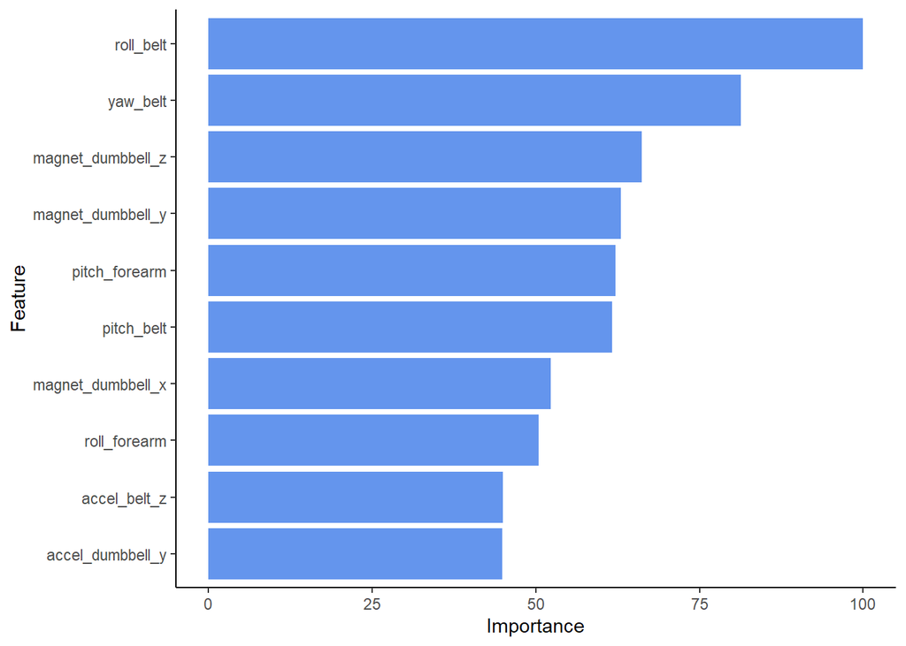

## Validation

The accuracy of the Random Forests model in the validation set is:

```r
# Validation
pred_out <- predict(model_rf, validation)
matrix_out <- confusionMatrix(validation$classe, pred_out)
acc_out <- matrix_out$overall[1]
```

```
##  Accuracy
## 0.9915881
```

## Expected out of sample error

```
##   Accuracy
## 0.00841193
```

```r
# OOB estimate of error
model_rf$finalModel
```

```
##
## Call:
##  randomForest(x = x, y = y, mtry = param$mtry)
##                Type of random forest: classification
##                      Number of trees: 500
## No. of variables tried at each split: 2
##
##         OOB estimate of  error rate: 0.91%
## Confusion matrix:
##      A    B    C    D    E class.error
## A 3344    2    0    1    1 0.001194743
## B   21 2250    8    0    0 0.012724879
## C    0   21 2030    3    0 0.011684518
## D    0    0   38 1890    2 0.020725389
## E    0    0    3    7 2155 0.004618938
```

## Test sample prediction

The prediction for the testing dataset using the Random Forests model is:

```r
predict(model_rf, plm_test)
```

```
##  [1] B A B A A E D B A A B C B A E E A B B B
## Levels: A B C D E
```